# E. coli non-O157 proteomics

Julian Trachsel

2022-08-26

### Limitations

#### **Summary of limitations**

This is a difficult experiment to extract reliable meaning from. Different from the O157 only experiment because there the strains used were all O157:H7, here each strain is a different serotype. This further complicates the analysis.

I suggest we frame this as a hypothesis generating bit of work. It identifies some interesting proteins to follow up with. These data probably wouldn’t stand on their own as a publication but could play a role as proof of expression in-vivo in the rumen and be a complement to other observations or data.

#### **Experimental design**

- Since this study has the same design as the “O157:H7 study” the same limitations on normalization techniques exist. Because the LC-MSMS run variable is confounded with the diet variable, any normalization to correct for ‘run’ bias will remove the diet effect as well. If we don’t correct for between run variation we will incorrectly assign this variation to the diets.
- We attempt to compare diets very broadly by using relative iBAQ values for each protein. This has its limitations as we essentially only have 1 sample from each diet that is a pool of the protein expression of 3 different serotypes. Therefore it will be very hard to discuss any specifics regarding the behavior of different serotypes. At best this could be a high level snapshot of broadly how STEC respond to different host diets in the rumen.
- The iBAQ analysis will have its biases too. Some of the proteins only detected from one diet will truly be differences related to the local environmental conditions the *E. coli* are experiencing. However, some of the proteins only detected in one run or or the other may be an artifact of being on different LC-MSMS runs. Even if you run the same sample across multiple different LC-MSMS runs, you may get proteins detected only in one run. This effect is most likely for lowly expressed proteins, as the highly expressed proteins are likely to be present across all runs.

Using the iTRAQ labels to compare in-vitro and in-vivo conditions is possible but also exhibits some issues.

#### **Low N makes normalizing methods less effective**

- The larger number of samples you have the more information you have to correct biases related to factors like iTRAQ label, peptide, run etc. ANOVA based methods that are commonly used may not have enough information to be effective and it’s difficult to understand if in-vitro vs in-vivo differences are due to a ‘sample prep / batch’ bias or are real biological differences.

### **Methods**

#### **Protein identification**

MaxQuant (cite) was used for peptide and protein identification, protein iBAQ quantification, and reporter ion intensity quantification. The Uniprot E. coli pan proteome (accession) was used as the search database. The parameter file describing all MaxQuant parameters used for these identifications is available. Only proteins identified by more than one peptide with Q values less than 0.05 are considered for these analyses.

#### **iBAQ methods**:

##### Description

iBAQ values comparing the abundance of proteins between the two diets were transformed into relative iBAQ (riBAQ) values. Each protein is represented by a single riBAQ value within each diet. To detect proteins which were differentially abundant within each diet the log2FoldChange was calculated by: log2(lact_riBAQ / maint_riBAQ). Proteins with an absolute log2FoldChange of greater than 1 were considered differentially abundant.

##### Code

```r
library(tidyverse)

# iBAQ
PG <- read_tsv('output/protein_groups_cleaned.tsv')
prot_descripts <- read_tsv('output/protein_descriptions.tsv')
# PG$Peptides

iBAQ_df <-
  PG %>%
  filter(!is.nan(iBAQ)) %>%
  filter(iBAQ != 0) %>%
  filter(Peptides > 1) %>%
  filter(!(grepl('CON', accno))) %>%
  select(accno, contains('iBAQ')) %>%
  transmute(accno,
            iBAQ_L=`iBAQ lactation`,
            iBAQ_M=`iBAQ maintenance`) %>%
  mutate(riBAQ_L=iBAQ_L/sum(iBAQ_L),
         riBAQ_M=iBAQ_M/sum(iBAQ_M)) %>%
  pivot_longer(names_to = c('type', 'condition'), names_sep = '_', values_to = 'value', cols = -c(accno))

p1 <-
  iBAQ_df %>%
  ggplot(aes(x=condition, y=value, fill=condition)) +
  geom_col(color='black') +
  facet_wrap(vars(type), scales = 'free') +
  ggtitle('Figure 1: Raw iBAQ and riBAQ normalized intensities')


riBAQ_df <- iBAQ_df %>% filter(type == 'riBAQ')

pseudo_val <- min(riBAQ_df$value[riBAQ_df$value !=0]) / 2

# riBAQ_df %>%
#   filter(value < .0001) %>%
#   ggplot(aes(x=(value))) +
#   geom_histogram(bins = 50)


riBAQ_res <-
  riBAQ_df %>%
  group_by(accno) %>%
  mutate(only_L=value[condition == 'L'] > 0 & value[condition == 'M'] == 0,
         only_M=value[condition == 'M'] > 0 & value[condition == 'L'] == 0,
         both=only_L == only_M) %>%
  ungroup() %>%
  mutate(value=value + pseudo_val) %>%
  group_by(accno) %>%
  summarise(only_L=unique(only_L), only_M=unique(only_M),both=unique(both),
            l2FC=log2(value[condition=='L']/value[condition== 'M']))


# THIS ONE
p2 <-
  riBAQ_res %>%
  ggplot(aes(x=l2FC, fill=both)) +
  geom_histogram(bins=50)+
  lims(x=c(-17,17),
       y=c(0,100)) +
  annotate(x=9, y=50, geom='label', label='Enriched in Lactation')+
  annotate(x=-9, y=50, geom='label', label='Enriched in Maintenance')+
  geom_vline(xintercept = 0)+
  labs(fill='Detected in both diets',
       y='count') +
  theme(legend.position = 'bottom')+
  ggtitle('Figure 2: Histogram of all log2FoldChange values')


# THIS ONE SIGS
p3 <- riBAQ_res %>%
  filter(abs(l2FC) > 1) %>%
  arrange((l2FC)) %>%
  left_join(prot_descripts) %>%
  ggplot(aes(x=l2FC, fill=both)) +
  annotate(x=9, y=50, geom='label', label='Enriched in Lactation')+
  annotate(x=-9, y=50, geom='label', label='Enriched in Maintenance')+
  geom_vline(xintercept = 0)+
  geom_histogram(bins=50)+
  lims(x=c(-17,17),
       y=c(0,100))+
  labs(fill='Detected in both diets',
       y='count') +
  theme(legend.position = 'bottom')+
  ggtitle('Figure 3: Histogram of log2FoldChange values  > 1')



sig_L_iBAQ <-
  riBAQ_res %>%
  filter(l2FC > 1) %>%
  arrange(desc(l2FC)) %>%
  left_join(prot_descripts)

up_L_iBAQ <- nrow(sig_L_iBAQ)

sig_M_iBAQ <-
  riBAQ_res %>%
  filter(l2FC < -1) %>%
  arrange(l2FC) %>%
  left_join(prot_descripts)


up_M_iBAQ <- nrow(sig_M_iBAQ)


##
num_not_not_diff <- riBAQ_res %>%
  filter(abs(l2FC) < 1) %>% nrow()

#
num_only_L <- riBAQ_res$only_L %>% sum()
num_only_M <- riBAQ_res$only_M %>% sum()
num_both <- riBAQ_res$both %>% sum()
total <- nrow(riBAQ_res)

# num proteins detected
T1 <- tribble(~category, ~ 'number of proteins',
        'total',total,
        'both diets',num_both,
        'lactation only',num_only_L,
        'maintenance only',num_only_M)


# 'sig' different proteins
T2 <- tribble(~category, ~'number of proteins',
        'not different', num_not_not_diff,
        'up in lactation',up_L_iBAQ,
        'up in maintenance',up_M_iBAQ)

# membrane prots up in L
T3 <- sig_L_iBAQ %>% filter(both)%>%
  filter(grepl('Mem', Localization))%>%
  select(accno, l2FC, description, Localization)


T4 <- sig_L_iBAQ %>%
  select(accno, l2FC, description, Localization)

# membrane prots up in M
T5 <- sig_M_iBAQ %>% filter(both) %>%
  filter(grepl('Mem', Localization)) %>%
  select(accno, l2FC, description, Localization)

T6 <- sig_M_iBAQ %>%
  select(accno, l2FC, description, Localization)





exp_design_tibble <-
  tibble(strain=paste0('Strain', rep(c(1:3),4)),
         condition=rep(c(rep('vivo', 3), rep('vitro', 3)),2),
         diet=c(rep('Lact', 6), rep('maint', 6)),
         LC_MSMS_run=c(rep('Run1',6), rep('Run2',6)),
         iTRAQ_label=c(1:6, 1:6))
#
```

#### **iTRAQ methods**:

##### Description

Two different methods were tested to normalize reporter ion intensities.

NOMAD, [Normalization of mass spectrometry data](https://pubmed.ncbi.nlm.nih.gov/29174395/), was used to normalize peptide reporter ion intensities and aggregate peptide reporter ion intensities to protein level intensities. This type of normalization is similar to what can be performed in Scaffold.

In addition, centered log ratios (clr) were used to normalize aggregated protein intensities. This is a more general normalization that can be performed on many different ‘-omics’ data. See [A field guide for the compositional analysis of any-omics data](https://www.ncbi.nlm.nih.gov/pmc/articles/PMC6755255/).

Differentially abundant proteins between in-vivo and in-vitro conditions were determined using T-tests and P values were corrected by the FDR method.

###### **IMPORTANT!!**

iTRAQ reporters 1, 2, and 3 were assumed to be the in-vivo condition.  
iTRAQ reporters 4, 5, and 6 were assumed to be the in-vitro condition.

If this is incorrect, the group labels in this report are reversed.

###### Experimental Design used in these analyses

| strain | condition | diet | LC_MSMS_run | iTRAQ_label |
| --- | --- | --- | --- | --- |
| Strain1 | vivo | Lact | Run1 | 1 |
| Strain2 | vivo | Lact | Run1 | 2 |
| Strain3 | vivo | Lact | Run1 | 3 |
| Strain1 | vitro | Lact | Run1 | 4 |
| Strain2 | vitro | Lact | Run1 | 5 |
| Strain3 | vitro | Lact | Run1 | 6 |
| Strain1 | vivo | maint | Run2 | 1 |
| Strain2 | vivo | maint | Run2 | 2 |
| Strain3 | vivo | maint | Run2 | 3 |
| Strain1 | vitro | maint | Run2 | 4 |
| Strain2 | vitro | maint | Run2 | 5 |
| Strain3 | vitro | maint | Run2 | 6 |

##### Code

```r
library(tidyverse)
library(vegan)
library(broom)
library(NOMAD)

# function for running tests on clr normalized data
run_tests <-
  function(matrix){
    # browser()
    tst <-
      matrix %>%
      as.data.frame() %>%
      rownames_to_column(var='ID') %>%
      separate(ID, into=c('strain', 'condition'),remove = FALSE) %>%
      mutate(condition=factor(condition, levels = c('vitro', 'vivo'))) %>%
      pivot_longer(names_to = 'accno', values_to = 'intensity', -c(ID, strain, condition)) %>%
      group_by(accno) %>%
      nest() %>%
      mutate(TTEST=map(.x=data,
                       .f=~t.test(formula=intensity ~ condition, data=.x) %>% tidy())) %>%
      select(-data) %>%
      unnest(TTEST) %>%
      ungroup() %>%
      mutate(FDR=p.adjust(p.value, method = 'fdr')) %>%
      arrange(estimate)
    return(tst)
  }

# function for running NOMAD normalization and ttests
NOMAD_diff_expression_tests <-
  function(long_peptides){

    NOMAD_NORM <- nomadNormalization(y=long_peptides$Abundance, x=long_peptides, factors = list('Peptide', 'iTRAQ'))
    nomad_proteins <- nomadAssembleProteins(NOMAD_NORM$y, NOMAD_NORM$x)

    TESTS <-
      nomad_proteins$scores %>%
      as.data.frame() %>%
      rownames_to_column(var='accno') %>%
      pivot_longer(cols = -accno, values_to = 'intensity') %>%
      mutate(reporter=sub('Run1_iTRAQ','',name),
             condition=ifelse(reporter %in% c(1,2,3), 'vivo', 'vitro'),
             condition=factor(condition, levels = c('vitro', 'vivo')),
             strain=case_when(
               reporter %in% c(1,4) ~'strain1',
               reporter %in% c(2,5) ~'strain2',
               reporter %in% c(3,6) ~'strain3'
             )) %>%
      group_by(accno) %>%
      mutate(VAR=var(intensity)) %>%
      filter(VAR != 0) %>%#pull(accno) %>% unique()
      nest() %>%
      mutate(TTEST=map(.x=data,
                       .f=~t.test(formula=intensity ~ condition, data=.x) %>% tidy())) %>%
      select(-data) %>%
      unnest(TTEST) %>%
      ungroup() %>%
      mutate(FDR=p.adjust(p.value, method = 'fdr')) %>%
      arrange(estimate)
    return(TESTS)
  }


# output of maxquant, protein groups
# filtered to only consider proteins that make the cutoffs

PG <-
  read_tsv('output/protein_groups_cleaned.tsv') %>%
  filter(`Q-value` < 0.05) %>%
  filter(Peptides > 1) %>%
  filter(!grepl('CON__', accno))

valid_accnos <- PG %>% pull(accno)
##########

# Peptide level intensities for NOMAD
ALL_PEPTIDES <- read_tsv('maxquant_results/combined/txt/peptides.txt')

ALL_PEPTIDES <-
  ALL_PEPTIDES %>%
  select(Sequence,`Leading razor protein`,  matches('Reporter intensity . [a-z]+')) %>%
  mutate(Protein=`Leading razor protein`,
         Peptide=Sequence) %>%
  select(Protein, Peptide,everything(), -`Leading razor protein`, -Sequence) %>%
  mutate(
    tmp_id=str_split(gsub('REV__tr','',Protein), pattern = '\\|'),
    first_underscore=map_int(tmp_id, ~min(grep('_', .x)))) %>%
  # select(first_underscore, tmp_id) %>%
  mutate(TMP=map2_chr(tmp_id,first_underscore, ~pluck(.x,.y) ),
         TMP=sub(';$','',TMP),
         TMP=sub(';[trsp]+$','',TMP),
         TMP=sub('REV__', '', TMP),
         Protein=TMP) %>%
  select(-first_underscore, -tmp_id, -TMP) %>%
  filter(Protein %in% valid_accnos)



LONG_PEPTIDES <-
  ALL_PEPTIDES %>%
  pivot_longer(cols = -c(Protein, Peptide), names_to = 'Sample', values_to = 'Abundance') %>%
  mutate(iTRAQ=sub('Reporter intensity ([0-8]+) [a-z]+','\\1',Sample),
         Run=sub('Reporter intensity ([0-8]+) ([a-z]+)','\\2',Sample),) %>%
  select(-Sample) %>%
  filter(iTRAQ %in% c(1:6))%>%
  filter(!grepl('CON', Protein))
# summary_stats


protein_summary <-
  LONG_PEPTIDES %>%
  filter(Abundance > 0) %>%
  group_by(Run,Protein) %>%
  summarise(num_peptides=sum(length(unique(Peptide))), .groups = 'drop')

run_summary <-
  protein_summary %>%
  filter(num_peptides >1) %>%
  group_by(Run) %>%
  summarise(tot_proteins=sum(length(unique(Protein))))



unique_proteins <-
  protein_summary %>%
  filter(num_peptides >1) %>%
  summarise(lactation=sum(!(Protein[Run == 'lactation'] %in% Protein[Run == 'maintenance'])),
            maintenance=sum(!(Protein[Run == 'maintenance'] %in% Protein[Run == 'lactation'])),
            both=sum((Protein[Run == 'lactation'] %in% Protein[Run == 'maintenance']))) %>%
  pivot_longer(cols=everything(),names_to = 'Run', values_to = 'unique_proteins')

### USE THIS TABLE
# unique_proteins %>% add_row(Run='total', unique_proteins=sum(unique_proteins$unique_proteins))


lact_peptides <-
  LONG_PEPTIDES %>%
  filter(Run == 'lactation' & Abundance > 0) %>%
  # filter(Run == 'lactation') %>%
  mutate(Run=1)


maint_peptides <-
  LONG_PEPTIDES %>%
  filter(Run == 'maintenance'& Abundance > 0) %>%
  # filter(Run == 'lactation') %>%
  mutate(Run=1)



LACT_TESTS <- NOMAD_diff_expression_tests(long_peptides = lact_peptides)
MAINT_TESTS <- NOMAD_diff_expression_tests(long_peptides = maint_peptides)


p_NOMAD_LACT_HIST <-
  LACT_TESTS %>%
  # filter(p.value < 0.05) %>%
  ggplot(aes(x=estimate, fill=ifelse(p.value < 0.05, T, F))) +
  annotate(x=2, y=50, geom='label', label='Enriched in vivo')+
  annotate(x=-2, y=50, geom='label', label='Enriched in vitro')+
  geom_histogram() + xlim(-3,3)+
  geom_vline(xintercept = 0) +
  labs(y='count',
       fill='P < 0.05')+
  theme(legend.position = 'bottom')

p_NOMAD_MAINT_HIST <-
  MAINT_TESTS %>%
  # filter(p.value < 0.05) %>%
  ggplot(aes(x=estimate, fill=ifelse(p.value < 0.05, T, F))) +
  annotate(x=2, y=50, geom='label', label='Enriched in vivo')+
  annotate(x=-2, y=50, geom='label', label='Enriched in vitro')+
  geom_histogram() + xlim(-3,3)+
  geom_vline(xintercept = 0) +
  labs(y='count',
       fill='P < 0.05')+
  theme(legend.position = 'bottom')
# All 'sigs' are more abundant in the vivo condition in both the lact and maint diets



# This section for t.tests with other normalization techniques

tibble(strain=paste0('Strain', rep(c(1:3),4)),
       condition=rep(c(rep('vivo', 3), rep('vitro', 3)),2),
       diet=c(rep('Lact', 6), rep('maint', 6)),
       LC_MSMS_run=c(rep('Run1',6), rep('Run2',6)),
       iTRAQ_label=c(1:6, 1:6))
#
```

```r
iTRAQ <-
  PG %>%
  select(accno, contains('Reporter intensity corrected')) %>%
  pivot_longer(-accno, names_to = c('reporter', 'treatment'),
               names_prefix = 'Reporter intensity corrected ',
               names_sep = ' ', values_to = 'intensity')

#  itraq reporter intensities
iTRAQ %>%
  ggplot(aes(x=reporter, y=intensity)) +
  geom_col(color='black') +
  facet_wrap(~treatment)



iTRAQ <-
  iTRAQ %>%
  filter(reporter %in% c(1:6)) %>% # only 6 of the 8 reporters used
  group_by(reporter, treatment) %>%
  mutate(rel_intensity=intensity/sum(intensity),
         log_intensity=log(intensity),
         # log_ratio_intensity=log_intensity/sum(log_intensity),
         condition=ifelse(reporter %in% c(1,2,3), 'vivo', 'vitro'),
         strain=case_when(
           reporter %in% c(1,4) ~'strain1',
           reporter %in% c(2,5) ~'strain2',
           reporter %in% c(3,6) ~'strain3'
         )) %>%
  ungroup()

iTRAQ %>%
  ggplot(aes(x=reporter, y=log_intensity, fill=condition)) +
  geom_col(color='black') +
  facet_wrap(~treatment)

iTRAQ %>%
  ggplot(aes(x=reporter, y=rel_intensity, fill=condition)) +
  geom_col(color='black') +
  facet_wrap(~treatment)

# this shows us that within each MSMS run we only dectect proteins that
# were detectable in all strains across both in-vivo and in-vitro conditions.
iTRAQ %>%
  group_by(treatment, accno) %>%
  summarise(ANY=any(intensity == 0),
            ALL=all(intensity == 0)) %>%
  ungroup() %>%
  mutate(ANY_NOT_ALL=ANY & !ALL) %>%
  filter(ANY_NOT_ALL)

###

iTRAQ_L <-
  iTRAQ %>%
  filter(treatment == 'lactation' & is.finite(log_intensity)) %>%
  group_by(reporter) %>%
  mutate(norm_log_intensity=log_intensity - mean(log_intensity)) %>%
  ungroup()



iTRAQ_L %>%
  ggplot(aes(x=reporter, y=norm_log_intensity, fill=condition)) +
  geom_col(color='black') +
  facet_wrap(~treatment)



iTRAQ_L_mat <-
  iTRAQ_L %>%
  select(accno, strain, condition, intensity) %>%
  pivot_wider(names_from = c(strain, condition), values_from = intensity ) %>%
  column_to_rownames('accno') %>% as.matrix() %>% t()


iTRAQ_L_mat <- iTRAQ_L_mat[,colSums(iTRAQ_L_mat) != 0]
iTRAQ_L_mat_log <- apply(iTRAQ_L_mat, c(1,2), FUN = log)
iTRAQ_L_mat_log_ratio <- t(scale(t(iTRAQ_L_mat_log), scale=FALSE))
iTRAQ_L_mat_clr <- decostand(x = iTRAQ_L_mat, method = 'clr')
iTRAQ_L_mat_rab <- decostand(x = iTRAQ_L_mat, method = 'total')
iTRAQ_L_mat_log_rab <- decostand(x = iTRAQ_L_mat_log, method = 'total')

hist(iTRAQ_L_mat_log_rab)

raw_tests <-
  run_tests(iTRAQ_L_mat) %>%
  mutate(order=1:n(),
         method='raw')


nomad_tests <-
  LACT_TESTS %>%
  mutate(order=1:n(),
         method='nomad')

clr_tests <-
  run_tests(iTRAQ_L_mat_clr) %>%
  mutate(order=1:n(),
         method='clr')

rab_tests <-  run_tests(iTRAQ_L_mat_rab) %>%
  mutate(order=1:n(),
         method='rab')

log_rab_tests <-  run_tests(iTRAQ_L_mat_log_rab) %>%
  mutate(order=1:n(),
         method='log_rab')

log_tests <-
  run_tests(iTRAQ_L_mat_log) %>%
  mutate(order=1:n(),
         method='log')

#


all_tests <-
  bind_rows(raw_tests, nomad_tests,clr_tests, rab_tests, log_rab_tests, log_tests) %>%
  group_by(accno) %>%
  mutate(MEAN_ORDER=mean(order),
         ref_order=order[method=='rab']) %>%
  mutate(SIG=ifelse(p.value < 0.05, T, F))

#
#
# all_tests <-
#   bind_rows(raw_tests, nomad_tests,clr_tests, rab_tests, log_rab_tests, log_tests) %>%
#   group_by(accno) %>%
#   mutate(MEAN_ORDER=mean(order),
#          ref_order=order[method=='nomad'])

#
all_tests %>%
  ggplot(aes(x=order, y=ref_order, fill=SIG,)) +
  geom_point(shape=21) +
  facet_wrap(~method+SIG)

all_tests %>%
  ggplot(aes(x=estimate, y=p.value, fill=SIG,)) +
  geom_point(shape=21) +
  facet_wrap(~method+SIG, scales = 'free')

all_tests %>% ggplot(aes(x=estimate, fill=SIG))+geom_histogram()+
  facet_wrap(~method, scales = 'free') +
  geom_vline(xintercept = 0)


META <-
  tibble(ID=rownames(iTRAQ_L_mat_clr)) %>%
  separate(ID, into=c('strain', 'condition'), remove = F)


plot(metaMDS(iTRAQ_L_mat_clr, distance = 'euclidean', autotransform = FALSE))
NMDS <- metaMDS(iTRAQ_L_mat_clr, distance = 'euclidean', autotransform = FALSE)

prot_NMDS_coords <- NMDS$species %>% as.data.frame() %>% rownames_to_column(var='accno')


META <-
  NMDS$points %>%
  as.data.frame() %>%
  rownames_to_column(var='ID') %>%
  left_join(META)


NMDS_plot <-
  META %>%
  ggplot(aes(x=MDS1, y=MDS2, fill=condition, label=strain)) +
  # geom_point()+
  geom_label() +
  theme_bw() +
  lims(x=c(-8,8), y=c(-6,6))

adonis_results <- adonis2(method = 'euclidean',data = META, formula = iTRAQ_L_mat_clr ~ strain * condition)

tst_clr <-
  iTRAQ_L_mat_clr %>%
  as.data.frame() %>%
  rownames_to_column(var='ID') %>%
  separate(ID, into=c('strain', 'condition'),remove = FALSE) %>%
  pivot_longer(names_to = 'accno', values_to = 'intensity', -c(ID, strain, condition)) %>%
  group_by(accno) %>%
  nest() %>%
  mutate(TTEST=map(.x=data,
                   .f=~t.test(formula=intensity ~ condition, data=.x) %>% tidy())) %>%
  select(-data) %>%
  unnest(TTEST) %>%
  ungroup() %>%
  mutate(FDR=p.adjust(p.value, method = 'fdr')) %>%
  arrange(p.value)

tst_log_ratios <-
  iTRAQ_L_mat_log_ratio %>%
  as.data.frame() %>%
  rownames_to_column(var='ID') %>%
  separate(ID, into=c('strain', 'condition'),remove = FALSE) %>%
  pivot_longer(names_to = 'accno', values_to = 'intensity', -c(ID, strain, condition)) %>%
  group_by(accno) %>%
  nest() %>%
  mutate(TTEST=map(.x=data,
                   .f=~t.test(formula=intensity ~ condition, data=.x) %>% tidy())) %>%
  select(-data) %>%
  unnest(TTEST) %>%
  ungroup() %>%
  mutate(FDR=p.adjust(p.value, method = 'fdr')) %>%
  arrange(p.value)

tst_raw_log <-
  iTRAQ_L_mat_log %>%
  as.data.frame() %>%
  rownames_to_column(var='ID') %>%
  separate(ID, into=c('strain', 'condition'),remove = FALSE) %>%
  pivot_longer(names_to = 'accno', values_to = 'intensity', -c(ID, strain, condition)) %>%
  group_by(accno) %>%
  nest() %>%
  mutate(TTEST=map(.x=data,
                   .f=~t.test(formula=intensity ~ condition, data=.x) %>% tidy())) %>%
  select(-data) %>%
  unnest(TTEST) %>%
  ungroup() %>%
  mutate(FDR=p.adjust(p.value, method = 'fdr')) %>%
  arrange(p.value)
tst_raw_log$estimate %>% hist()
```

```r
#########


iTRAQ_M <- iTRAQ %>% filter(treatment == 'maintenance')


iTRAQ_M_mat <-
  iTRAQ_M %>%
  select(accno, strain, condition, intensity) %>%
  pivot_wider(names_from = c(strain, condition), values_from = intensity ) %>%
  column_to_rownames('accno') %>% as.matrix() %>% t()



iTRAQ_M_mat <- iTRAQ_M_mat[,colSums(iTRAQ_M_mat) != 0]
library(vegan)
iTRAQ_M_mat_clr <- decostand(x = iTRAQ_M_mat, method = 'clr')


any(colSums(iTRAQ_L_mat) == 0)


adonis2(method = 'euclidean',data = META, formula = iTRAQ_M_mat_clr ~ strain + condition)





tst_clr %>%
  mutate(FDR=p.adjust(p.value, 'fdr')) %>%
  mutate(l2fc=log(estimate1/estimate2)) %>%
  arrange(l2fc)

###

# tests on raw log2 transformed intensities




####
# Relative abundance methods
# paired or unpaired T.test, doesnt really matter, very few sig diffs btw proteins in L
# none in M

tst <-
  iTRAQ_L %>%
  select(-intensity, -reporter) %>%
  pivot_wider(names_from = condition, values_from = rel_intensity ) %>%
  group_by(accno) %>%
  nest() %>%
  mutate(ttest=map(.x = data, ~t.test(.x$vitro, .x$vivo) %>% tidy())) %>%
  select(accno, ttest) %>%
  unnest(ttest) %>%
  ungroup() %>%
  filter(!is.nan(p.value)) %>%
  mutate(FDR=p.adjust(p.value, 'fdr')) %>%
  arrange(FDR)
  tst$method
# t.test(x=tst$data[[1]]$vivo, y=tst$data[[1]]$vitro, paired = T) %>% tidy()

iTRAQ_L %>% group_by(accno) %>% nest() %>%
mutate(lms=map(.x = data, ~lm(data = .x, formula=rel_intensity~condition)),
         res=map(.x=lms, .f=~tidy(.x, conf.int=T) %>%
                   filter(term=='conditionvivo'))) %>%
  select(accno, res) %>%
  unnest(res) %>%
  ungroup() %>%
  filter(!is.nan(p.value)) %>%
  mutate(FDR=p.adjust(p =p.value, method = 'fdr')) %>%
  arrange((FDR))

iTRAQ_M_res <-
  iTRAQ_M %>%
  select(-intensity, -reporter) %>%
  pivot_wider(names_from = condition, values_from = rel_intensity ) %>%
  group_by(accno) %>%
  nest() %>%
  mutate(ttest=map(.x = data, ~t.test(.x$vitro, .x$vivo, paired=T) %>% tidy())) %>%
  select(accno, ttest) %>%
  unnest(ttest) %>%
  ungroup() %>%
  filter(!is.nan(p.value)) %>%
  mutate(FDR=p.adjust(p.value, 'fdr')) %>%
  arrange(FDR)

######## multivariate analyses #########
# relative abundance, bray curtis dissimilarities
tst <- iTRAQ_L %>%
  select(accno, strain, condition, rel_intensity) %>%
  pivot_wider(names_from = c(strain, condition), values_from = rel_intensity) %>%
  column_to_rownames(var='accno') %>% as.matrix() %>% t()

tst[1:6, 1:3]

tst <- tst[,colSums(tst) != 0]

library(vegan)
library(ggrepel)
MDS_tst <- metaMDS(tst)
META <- MDS_tst$points %>% as.data.frame() %>% rownames_to_column(var="ID") %>%
  separate(ID, into = c('strain', 'condition'))
META %>%
  ggplot(aes(x=MDS1, y=MDS2)) + geom_point(aes(fill=condition), shape=21)+geom_text_repel(aes(label=strain))
vegan::vegdist(tst)

adonis2(data = META, formula = tst ~ condition + strain)



###
```

### **iBAQ results**

#### **Overview**

##### **Table 1: Detected proteins**

| category | number of proteins |
| --- | --- |
| total | 446 |
| both diets | 379 |
| lactation only | 26 |
| maintenance only | 41 |

##### **Table 2: Differentially abundant proteins**

| category | number of proteins |
| --- | --- |
| not different | 173 |
| up in lactation | 80 |
| up in maintenance | 193 |

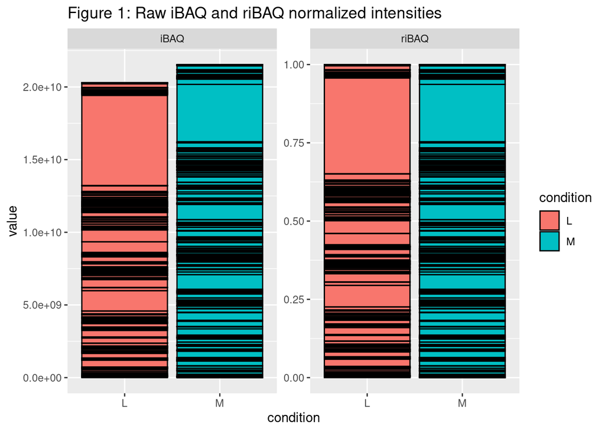

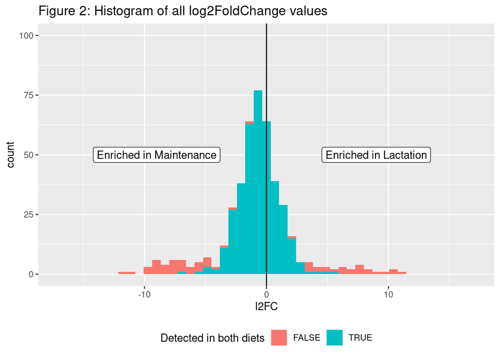

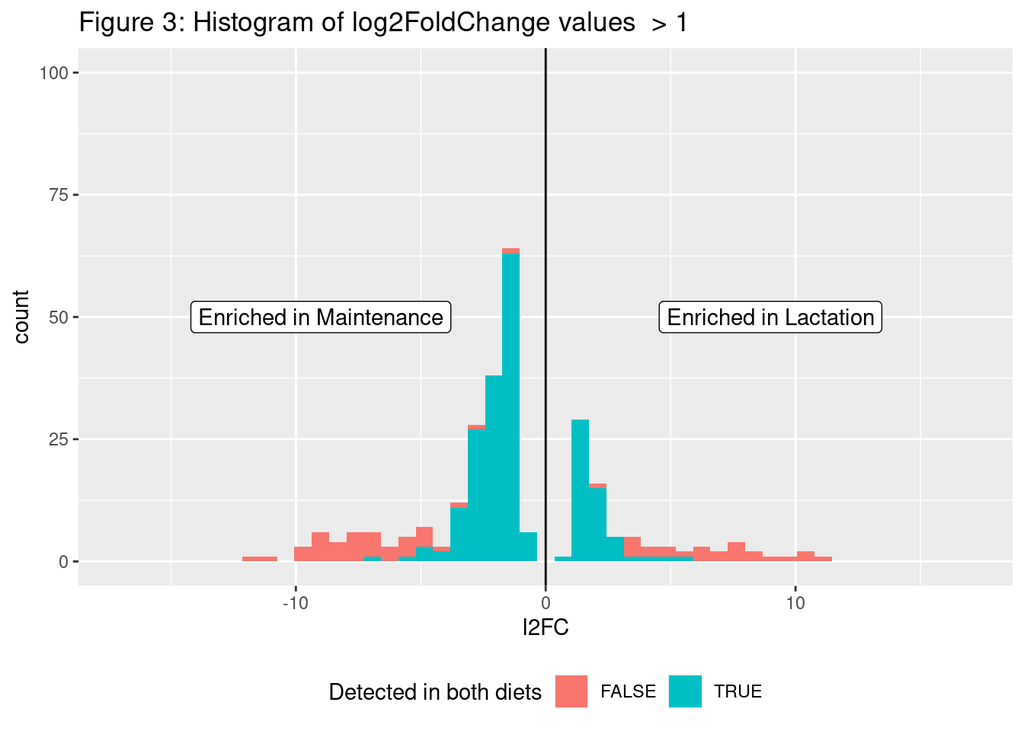

#### **Lactation Enriched**

##### **Membrane Associated Proteins**

| accno | l2FC | description | Localization |
| --- | --- | --- | --- |
| LAMB_ECOLI | 4.013676 | Maltoporin OS=Escherichia coli (strain K12) OX=83333 GN=lamB PE=1 SV=1 UPId=UP000000625 PPId=UP000000625 | OuterMembrane |
| BTUB_ECOLI | 2.825855 | Vitamin B12 transporter BtuB OS=Escherichia coli (strain K12) OX=83333 GN=btuB PE=1 SV=2 UPId=UP000000625 PPId=UP000000625 | OuterMembrane |
| LPTD_ECOLI | 2.494026 | LPS-assembly protein LptD OS=Escherichia coli (strain K12) OX=83333 GN=lptD PE=1 SV=2 UPId=UP000000625 PPId=UP000000625 | OuterMembrane |
| GFCE_ECOLI | 2.246619 | Putative polysaccharide export protein GfcE OS=Escherichia coli (strain K12) OX=83333 GN=gfcE PE=3 SV=1 UPId=UP000000625 PPId=UP000000625 | OuterMembrane |
| OMPT_ECOLI | 2.241507 | Protease 7 OS=Escherichia coli (strain K12) OX=83333 GN=ompT PE=1 SV=1 UPId=UP000000625 PPId=UP000000625 | OuterMembrane |
| OMPX_ECOLI | 1.908818 | Outer membrane protein X OS=Escherichia coli (strain K12) OX=83333 GN=ompX PE=1 SV=1 UPId=UP000000625 PPId=UP000000625 | OuterMembrane |
| BAMD_ECOLI | 1.891539 | Outer membrane protein assembly factor BamD OS=Escherichia coli (strain K12) OX=83333 GN=bamD PE=1 SV=1 UPId=UP000000625 PPId=UP000000625 | OuterMembrane |
| TOLC_ECOLI | 1.726408 | Outer membrane protein TolC OS=Escherichia coli (strain K12) OX=83333 GN=tolC PE=1 SV=3 UPId=UP000000625 PPId=UP000000625 | OuterMembrane |
| LPOA_ECOLI | 1.517984 | Penicillin-binding protein activator LpoA OS=Escherichia coli (strain K12) OX=83333 GN=lpoA PE=1 SV=1 UPId=UP000000625 PPId=UP000000625 | CytoplasmicMembrane |
| W1EVD7_ECOLX | 1.516311 | Outer membrane protein assembly factor BamB OS=Escherichia coli ISC7 OX=1432555 GN=bamB PE=3 SV=1 UPId=UP000019199 PPId=UP000000625 | OuterMembrane |
| FHUA_ECOLI | 1.380996 | Ferrichrome outer membrane transporter/phage receptor OS=Escherichia coli (strain K12) OX=83333 GN=fhuA PE=1 SV=2 UPId=UP000000625 PPId=UP000000625 | OuterMembrane |
| ACRB_ECOLI | 1.318815 | Multidrug efflux pump subunit AcrB OS=Escherichia coli (strain K12) OX=83333 GN=acrB PE=1 SV=1 UPId=UP000000625 PPId=UP000000625 | CytoplasmicMembrane |
| NARG_ECOLI | 1.261149 | Respiratory nitrate reductase 1 alpha chain OS=Escherichia coli (strain K12) OX=83333 GN=narG PE=1 SV=4 UPId=UP000000625 PPId=UP000000625 | CytoplasmicMembrane |
| SLYB_ECOLI | 1.165489 | Outer membrane lipoprotein SlyB OS=Escherichia coli (strain K12) OX=83333 GN=slyB PE=2 SV=1 UPId=UP000000625 PPId=UP000000625 | OuterMembrane |
| OMPW_ECOLI | 1.154323 | Outer membrane protein W OS=Escherichia coli (strain K12) OX=83333 GN=ompW PE=1 SV=1 UPId=UP000000625 PPId=UP000000625 | OuterMembrane |

##### **All Proteins**

| accno | l2FC | description | Localization |
| --- | --- | --- | --- |
| RL20_ECOLI | 10.976466 | 50S ribosomal protein L20 OS=Escherichia coli (strain K12) OX=83333 GN=rplT PE=1 SV=2 UPId=UP000000625 PPId=UP000000625 | Cytoplasmic |
| RS9_ESCF3 | 10.693025 | 30S ribosomal protein S9 OS=Escherichia fergusonii (strain ATCC 35469 / DSM 13698 / CCUG 18766 / IAM 14443 / JCM 21226 / LMG 7866 / NBRC 102419 / NCTC 12128 / CDC 0568-73) OX=585054 GN=rpsI PE=3 SV=1 … | Cytoplasmic |
| RL2_SHIDS | 10.384522 | 50S ribosomal protein L2 OS=Shigella dysenteriae serotype 1 (strain Sd197) OX=300267 GN=rplB PE=3 SV=1 UPId=UP000002716 PPId=UP000000625 | Cytoplasmic |
| A0A3Q0N561_ECOLX | 10.056178 | Uncharacterized protein OS=Escherichia coli OX=562 GN=CR539_25405 PE=4 SV=1 UPId=UP000234543 PPId=UP000000625 | OuterMembrane |
| A0A6H3MLA3_ECOLX | 8.869523 | Uncharacterized protein OS=Escherichia coli OX=562 GN=E5S35_23465 PE=4 SV=1 UPId=UP000297611 PPId=UP000000625 | Unknown |
| A0A485JPY6_ECOLX | 8.559887 | Maltoporin (Maltose-inducible porin) OS=Escherichia coli OX=562 GN=lamB_2 PE=3 SV=1 UPId=UP000358010 PPId=UP000000625 | OuterMembrane |
| A0A2X1J1B6_ECOLX | 8.160787 | Fibronectin-binding protein B OS=Escherichia coli OX=562 GN=lpoB PE=4 SV=1 UPId=UP000250561 PPId=UP000000625 | Unknown |
| A0A376YCI2_ECOLX | 7.523746 | Putative lipoprotein OS=Escherichia coli OX=562 GN=NCTC9117_04716 PE=4 SV=1 UPId=UP000254785 PPId=UP000000625 | Unknown |
| A0A376KWW8_ECOLX | 7.501132 | Outer membrane protein A OS=Escherichia coli OX=562 GN=ompA_2 PE=3 SV=1 UPId=UP000255460 PPId=UP000000625 | OuterMembrane |
| A0A376U9E3_ECOLX | 7.383173 | Sulfurtransferase OS=Escherichia coli OX=562 GN=ynjE_1 PE=4 SV=1 UPId=UP000254079 PPId=UP000000625 | Periplasmic |
| GRPE_ECOLI | 7.361446 | Protein GrpE OS=Escherichia coli (strain K12) OX=83333 GN=grpE PE=1 SV=1 UPId=UP000000625 PPId=UP000000625 | Cytoplasmic |
| HDHA_ECOLI | 7.185007 | 7alpha-hydroxysteroid dehydrogenase OS=Escherichia coli (strain K12) OX=83333 GN=hdhA PE=1 SV=1 UPId=UP000000625 PPId=UP000000625 | Cytoplasmic |
| NUOG_ECOLI | 7.129528 | NADH-quinone oxidoreductase subunit G OS=Escherichia coli (strain K12) OX=83333 GN=nuoG PE=1 SV=4 UPId=UP000000625 PPId=UP000000625 | Cytoplasmic |
| A0A377C3N1_ECOLX | 6.406428 | 3-deoxy-D-manno-octulosonate 8-phosphate phosphatase KdsC OS=Escherichia coli OX=562 GN=kdsC_2 PE=3 SV=1 UPId=UP000254255 PPId=UP000000625 | Cytoplasmic |
| WZZB_ECOLI | 6.248959 | Chain length determinant protein OS=Escherichia coli (strain K12) OX=83333 GN=wzzB PE=1 SV=2 UPId=UP000000625 PPId=UP000000625 | CytoplasmicMembrane |
| U9Y675_ECOLX | 6.146508 | Antigen 43 domain protein (Fragment) OS=Escherichia coli 113290 OX=1268976 GN=HMPREF1589_04327 PE=4 SV=1 UPId=UP000017268 PPId=UP000000625 | Unknown |
| PHSM_ECOLI | 5.403328 | Maltodextrin phosphorylase OS=Escherichia coli (strain K12) OX=83333 GN=malP PE=1 SV=7 UPId=UP000000625 PPId=UP000000625 | Cytoplasmic |
| A0A484YMA4_ECOLX | 5.335289 | Peptidase Do OS=Escherichia coli OX=562 GN=degQ_2 PE=4 SV=1 UPId=UP000372890 PPId=UP000000625 | Periplasmic |
| HSLO_ECOLI | 4.973118 | 33 kDa chaperonin OS=Escherichia coli (strain K12) OX=83333 GN=hslO PE=1 SV=1 UPId=UP000000625 PPId=UP000000625 | Cytoplasmic |
| Q32AJ8_SHIDS | 4.587735 | Ribulose-phosphate 3-epimerase OS=Shigella dysenteriae serotype 1 (strain Sd197) OX=300267 GN=rpe PE=3 SV=1 UPId=UP000002716 PPId=UP000000625 | Cytoplasmic |
| DCP_ECOLI | 4.529636 | Dipeptidyl carboxypeptidase OS=Escherichia coli (strain K12) OX=83333 GN=dcp PE=1 SV=4 UPId=UP000000625 PPId=UP000000625 | Cytoplasmic |
| LAMB_ECOLI | 4.013676 | Maltoporin OS=Escherichia coli (strain K12) OX=83333 GN=lamB PE=1 SV=1 UPId=UP000000625 PPId=UP000000625 | OuterMembrane |
| A0A4C3ABB4_ECOLX | 3.934185 | Colicin IA outer membrane receptor and translocator OS=Escherichia coli OX=562 GN=cirA PE=3 SV=1 UPId=UP000300926 PPId=UP000000625 | OuterMembrane |
| MASZ_ECOLI | 3.882459 | Malate synthase G OS=Escherichia coli (strain K12) OX=83333 GN=glcB PE=1 SV=3 UPId=UP000000625 PPId=UP000000625 | Cytoplasmic |
| GMHA_ECOLI | 3.798608 | Phosphoheptose isomerase OS=Escherichia coli (strain K12) OX=83333 GN=gmhA PE=1 SV=1 UPId=UP000000625 PPId=UP000000625 | Cytoplasmic |
| A0A3P6L4I9_SHIDY | 3.698837 | Sulfatase OS=Shigella dysenteriae OX=622 GN=betC PE=3 SV=1 UPId=UP000274225 PPId=UP000000625 | Unknown |
| A0A826NG43_ECOLX | 3.599652 | Methionine–tRNA ligase OS=Escherichia coli OX=562 GN=CXJ73_005976 PE=3 SV=1 UPId=UP000551708 PPId=UP000000625 | Cytoplasmic |
| GFCD_ECOLI | 3.428450 | Uncharacterized lipoprotein GfcD OS=Escherichia coli (strain K12) OX=83333 GN=gfcD PE=3 SV=1 UPId=UP000000625 PPId=UP000000625 | OuterMembrane |
| A0A370VB07_9ESCH | 3.249670 | UDP-2,3-diacetamido-2,3-dideoxy-D-glucuronate 2-epimerase OS=Escherichia marmotae OX=1499973 GN=wbpI PE=3 SV=1 UPId=UP000254454 PPId=UP000000625 | Cytoplasmic |
| BTUB_ECOLI | 2.825855 | Vitamin B12 transporter BtuB OS=Escherichia coli (strain K12) OX=83333 GN=btuB PE=1 SV=2 UPId=UP000000625 PPId=UP000000625 | OuterMembrane |
| RL15_ECOLI | 2.796739 | 50S ribosomal protein L15 OS=Escherichia coli (strain K12) OX=83333 GN=rplO PE=1 SV=1 UPId=UP000000625 PPId=UP000000625 | Cytoplasmic |
| CDD_ECOLI | 2.767256 | Cytidine deaminase OS=Escherichia coli (strain K12) OX=83333 GN=cdd PE=1 SV=1 UPId=UP000000625 PPId=UP000000625 | Unknown |
| RL14_ECOLI | 2.575905 | 50S ribosomal protein L14 OS=Escherichia coli (strain K12) OX=83333 GN=rplN PE=1 SV=1 UPId=UP000000625 PPId=UP000000625 | Cytoplasmic |
| LPTD_ECOLI | 2.494026 | LPS-assembly protein LptD OS=Escherichia coli (strain K12) OX=83333 GN=lptD PE=1 SV=2 UPId=UP000000625 PPId=UP000000625 | OuterMembrane |
| A0A485JLJ4_ECOLX | 2.416273 | Glutaminyl-tRNA synthetase OS=Escherichia coli OX=562 GN=glnS_3 PE=3 SV=1 UPId=UP000358010 PPId=UP000000625 | Cytoplasmic |
| B7LL07_ESCF3 | 2.373743 | Maltodextrin-binding protein OS=Escherichia fergusonii (strain ATCC 35469 / DSM 13698 / CCUG 18766 / IAM 14443 / JCM 21226 / LMG 7866 / NBRC 102419 / NCTC 12128 / CDC 0568-73) OX=585054 GN=malE PE=3 S… | Periplasmic |
| I2UJY0_ECOLX | 2.344187 | Serine protease pic autotransporter OS=Escherichia coli 4.0522 OX=869681 GN=pic PE=4 SV=1 UPId=UP000004262 PPId=UP000000625 | Extracellular |
| A0A5B9ASM8_ECOLX | 2.311305 | 50S ribosomal protein L17 OS=Escherichia coli OX=562 GN=rplQ PE=3 SV=1 UPId=UP000321162 PPId=UP000000625 | Cytoplasmic |
| GFCE_ECOLI | 2.246619 | Putative polysaccharide export protein GfcE OS=Escherichia coli (strain K12) OX=83333 GN=gfcE PE=3 SV=1 UPId=UP000000625 PPId=UP000000625 | OuterMembrane |
| OMPT_ECOLI | 2.241507 | Protease 7 OS=Escherichia coli (strain K12) OX=83333 GN=ompT PE=1 SV=1 UPId=UP000000625 PPId=UP000000625 | OuterMembrane |
| B7MMG5_ECO45 | 2.230749 | Antigen 43 (AG43) (Fluffing protein) OS=Escherichia coli O45:K1 (strain S88 / ExPEC) OX=585035 GN=ECS88_4891 PE=4 SV=1 UPId=UP000000747 PPId=UP000000625 | OuterMembrane |
| RS15_ECOLI | 2.109506 | 30S ribosomal protein S15 OS=Escherichia coli (strain K12) OX=83333 GN=rpsO PE=1 SV=2 UPId=UP000000625 PPId=UP000000625 | Cytoplasmic |
| RL4_ECOLI | 2.066277 | 50S ribosomal protein L4 OS=Escherichia coli (strain K12) OX=83333 GN=rplD PE=1 SV=1 UPId=UP000000625 PPId=UP000000625 | Cytoplasmic |
| A0A377DYQ7_ECOLX | 2.039912 | Isoaspartyl dipeptidase OS=Escherichia coli OX=562 GN=iadA_1 PE=4 SV=1 UPId=UP000254429 PPId=UP000000625 | Cytoplasmic |
| OMPX_ECOLI | 1.908818 | Outer membrane protein X OS=Escherichia coli (strain K12) OX=83333 GN=ompX PE=1 SV=1 UPId=UP000000625 PPId=UP000000625 | OuterMembrane |
| BAMD_ECOLI | 1.891539 | Outer membrane protein assembly factor BamD OS=Escherichia coli (strain K12) OX=83333 GN=bamD PE=1 SV=1 UPId=UP000000625 PPId=UP000000625 | OuterMembrane |
| W1F098_ECOLX | 1.878861 | PTS system mannose-specific EIIAB component OS=Escherichia coli ISC7 OX=1432555 PE=4 SV=1 UPId=UP000019199 PPId=UP000000625 | Cytoplasmic |
| YBJP_ECOLI | 1.799920 | Uncharacterized lipoprotein YbjP OS=Escherichia coli (strain K12) OX=83333 GN=ybjP PE=1 SV=1 UPId=UP000000625 PPId=UP000000625 | Unknown |
| A0A1X3I7X1_ECOLX | 1.762646 | Glutamate/aspartate periplasmic-binding protein OS=Escherichia coli M056 OX=656415 GN=EAMG_00090 PE=4 SV=1 UPId=UP000193167 PPId=UP000000625 | Periplasmic |
| A0A485J825_ECOLX | 1.749155 | Glutathione reductase OS=Escherichia coli OX=562 GN=gor_2 PE=3 SV=1 UPId=UP000358010 PPId=UP000000625 | Cytoplasmic |
| TOLC_ECOLI | 1.726408 | Outer membrane protein TolC OS=Escherichia coli (strain K12) OX=83333 GN=tolC PE=1 SV=3 UPId=UP000000625 PPId=UP000000625 | OuterMembrane |
| GREA_ECOLI | 1.710078 | Transcription elongation factor GreA OS=Escherichia coli (strain K12) OX=83333 GN=greA PE=1 SV=1 UPId=UP000000625 PPId=UP000000625 | Cytoplasmic |
| UCPA_ECOLI | 1.691006 | Oxidoreductase UcpA OS=Escherichia coli (strain K12) OX=83333 GN=ucpA PE=1 SV=3 UPId=UP000000625 PPId=UP000000625 | Cytoplasmic |
| RL5_ECOLI | 1.687452 | 50S ribosomal protein L5 OS=Escherichia coli (strain K12) OX=83333 GN=rplE PE=1 SV=2 UPId=UP000000625 PPId=UP000000625 | Cytoplasmic |
| RS4_ECOLI | 1.661810 | 30S ribosomal protein S4 OS=Escherichia coli (strain K12) OX=83333 GN=rpsD PE=1 SV=2 UPId=UP000000625 PPId=UP000000625 | Cytoplasmic |
| STPA_ECOLI | 1.657791 | DNA-binding protein StpA OS=Escherichia coli (strain K12) OX=83333 GN=stpA PE=1 SV=1 UPId=UP000000625 PPId=UP000000625 | Cytoplasmic |
| RS18_ECOLI | 1.631660 | 30S ribosomal protein S18 OS=Escherichia coli (strain K12) OX=83333 GN=rpsR PE=1 SV=2 UPId=UP000000625 PPId=UP000000625 | Cytoplasmic |
| NUOCD_ECOLI | 1.625385 | NADH-quinone oxidoreductase subunit C/D OS=Escherichia coli (strain K12) OX=83333 GN=nuoC PE=1 SV=3 UPId=UP000000625 PPId=UP000000625 | Cytoplasmic |
| RL1_ECOLI | 1.614662 | 50S ribosomal protein L1 OS=Escherichia coli (strain K12) OX=83333 GN=rplA PE=1 SV=2 UPId=UP000000625 PPId=UP000000625 | Cytoplasmic |
| HSLU_ECOLI | 1.558619 | ATP-dependent protease ATPase subunit HslU OS=Escherichia coli (strain K12) OX=83333 GN=hslU PE=1 SV=1 UPId=UP000000625 PPId=UP000000625 | Cytoplasmic |
| W1W5Q0_ECOLX | 1.519924 | N utilization substance protein B-like protein (Fragment) OS=Escherichia coli DORA_A_5_14_21 OX=1403943 GN=Q609_ECAC02793G0001 PE=3 SV=1 UPId=UP000018853 PPId=UP000000625 | Unknown |
| LPOA_ECOLI | 1.517984 | Penicillin-binding protein activator LpoA OS=Escherichia coli (strain K12) OX=83333 GN=lpoA PE=1 SV=1 UPId=UP000000625 PPId=UP000000625 | CytoplasmicMembrane |
| W1EVD7_ECOLX | 1.516311 | Outer membrane protein assembly factor BamB OS=Escherichia coli ISC7 OX=1432555 GN=bamB PE=3 SV=1 UPId=UP000019199 PPId=UP000000625 | OuterMembrane |
| RL22_ECOLI | 1.468096 | 50S ribosomal protein L22 OS=Escherichia coli (strain K12) OX=83333 GN=rplV PE=1 SV=1 UPId=UP000000625 PPId=UP000000625 | Cytoplasmic |
| ADHE_ECOLI | 1.417414 | Bifunctional aldehyde-alcohol dehydrogenase AdhE OS=Escherichia coli (strain K12) OX=83333 GN=adhE PE=1 SV=2 UPId=UP000000625 PPId=UP000000625 | Cytoplasmic |
| FHUA_ECOLI | 1.380996 | Ferrichrome outer membrane transporter/phage receptor OS=Escherichia coli (strain K12) OX=83333 GN=fhuA PE=1 SV=2 UPId=UP000000625 PPId=UP000000625 | OuterMembrane |
| Q9LAN9_ECO57 | 1.352989 | Putative tellurium resistance protein B OS=Escherichia coli O157:H7 OX=83334 GN=tlrB PE=4 SV=1 UPId=UP000000558 PPId=UP000000625 | Cytoplasmic |
| A0A376TZH2_ECOLX | 1.340099 | 3-octaprenyl-4-hydroxybenzoate carboxy-lyase OS=Escherichia coli OX=562 GN=ubiD_1 PE=4 SV=1 UPId=UP000254079 PPId=UP000000625 | Cytoplasmic |
| A0A376L549_ECOLX | 1.337182 | Putative lipopolysaccharide core biosynthesis GTP-binding protein OS=Escherichia coli OX=562 GN=typA_1 PE=4 SV=1 UPId=UP000255460 PPId=UP000000625 | Cytoplasmic |
| ACRB_ECOLI | 1.318815 | Multidrug efflux pump subunit AcrB OS=Escherichia coli (strain K12) OX=83333 GN=acrB PE=1 SV=1 UPId=UP000000625 PPId=UP000000625 | CytoplasmicMembrane |
| NARG_ECOLI | 1.261149 | Respiratory nitrate reductase 1 alpha chain OS=Escherichia coli (strain K12) OX=83333 GN=narG PE=1 SV=4 UPId=UP000000625 PPId=UP000000625 | CytoplasmicMembrane |
| A0A376KSN5_ECOLX | 1.236811 | Dihydropyrimidine dehydrogenase OS=Escherichia coli OX=562 GN=yeiA_3 PE=4 SV=1 UPId=UP000255460 PPId=UP000000625 | Unknown |
| A0A8B4PR90_ECOLX | 1.169075 | Tryptophan–tRNA ligase OS=Escherichia coli OX=562 GN=trpS_1 PE=3 SV=1 UPId=UP000254335 PPId=UP000000625 | Cytoplasmic |
| SLYB_ECOLI | 1.165489 | Outer membrane lipoprotein SlyB OS=Escherichia coli (strain K12) OX=83333 GN=slyB PE=2 SV=1 UPId=UP000000625 PPId=UP000000625 | OuterMembrane |
| OMPW_ECOLI | 1.154323 | Outer membrane protein W OS=Escherichia coli (strain K12) OX=83333 GN=ompW PE=1 SV=1 UPId=UP000000625 PPId=UP000000625 | OuterMembrane |
| A0A229AGN3_ECOLX | 1.140604 | 30S ribosomal protein S3 OS=Escherichia coli OX=562 GN=rpsC PE=3 SV=1 UPId=UP000214591 PPId=UP000000625 | Cytoplasmic |
| Q7DBX3_ECO57 | 1.100986 | Tellurium resistance protein TerZ OS=Escherichia coli O157:H7 OX=83334 GN=terZ PE=4 SV=1 UPId=UP000000558 PPId=UP000000625 | Cytoplasmic |
| SODM_ECOLI | 1.083436 | Superoxide dismutase [Mn] OS=Escherichia coli (strain K12) OX=83333 GN=sodA PE=1 SV=2 UPId=UP000000625 PPId=UP000000625 | Unknown |
| PYRB_ECOLI | 1.055094 | Aspartate carbamoyltransferase catalytic subunit OS=Escherichia coli (strain K12) OX=83333 GN=pyrB PE=1 SV=2 UPId=UP000000625 PPId=UP000000625 | Cytoplasmic |
| W1W9J2_ECOLX | 1.030046 | Uncharacterized protein (Fragment) OS=Escherichia coli DORA_A_5_14_21 OX=1403943 GN=Q609_ECAC02578G0001 PE=4 SV=1 UPId=UP000018853 PPId=UP000000625 | Unknown |

#### **Maintenance Enriched**

##### **Membrane Associated Proteins**

| accno | l2FC | description | Localization |
| --- | --- | --- | --- |
| W1EVA6_ECOLX | -4.151770 | Alkyl hydroperoxide reductase subunit F OS=Escherichia coli ISC7 OX=1432555 PE=3 SV=1 UPId=UP000019199 PPId=UP000000625 | CytoplasmicMembrane |
| A0A376RLV2_ECOLX | -3.116414 | 3-oxoacyl-ACP synthase OS=Escherichia coli OX=562 GN=fabF_2 PE=4 SV=1 UPId=UP000254159 PPId=UP000000625 | CytoplasmicMembrane |
| A0A2X1JEG9_ECOLX | -2.475205 | Cytochrome d ubiquinol oxidase subunit III OS=Escherichia coli OX=562 GN=yhcB_1 PE=4 SV=1 UPId=UP000250561 PPId=UP000000625 | CytoplasmicMembrane |
| A0A2W6PUV2_ECOLX | -2.113754 | Glutamate dehydrogenase (Fragment) OS=Escherichia coli OX=562 GN=DNQ45_27270 PE=3 SV=1 UPId=UP000249482 PPId=UP000000625 | OuterMembrane |
| FABI_ECOLI | -1.951649 | Enoyl-[acyl-carrier-protein] reductase [NADH] FabI OS=Escherichia coli (strain K12) OX=83333 GN=fabI PE=1 SV=2 UPId=UP000000625 PPId=UP000000625 | CytoplasmicMembrane |
| SDHB_ECOLI | -1.840600 | Succinate dehydrogenase iron-sulfur subunit OS=Escherichia coli (strain K12) OX=83333 GN=sdhB PE=1 SV=1 UPId=UP000000625 PPId=UP000000625 | CytoplasmicMembrane |
| FRDA_ECOLI | -1.805903 | Fumarate reductase flavoprotein subunit OS=Escherichia coli (strain K12) OX=83333 GN=frdA PE=1 SV=3 UPId=UP000000625 PPId=UP000000625 | CytoplasmicMembrane |

##### **All Proteins**

| accno | l2FC | description | Localization |
| --- | --- | --- | --- |
| UDP_ECOLI | -11.840420 | Uridine phosphorylase OS=Escherichia coli (strain K12) OX=83333 GN=udp PE=1 SV=3 UPId=UP000000625 PPId=UP000000625 | Cytoplasmic |
| A0A377BWE3_ECOLX | -10.910258 | Peptidyl-prolyl cis-trans isomerase OS=Escherichia coli OX=562 GN=slyD PE=3 SV=1 UPId=UP000254088 PPId=UP000000625 | Cytoplasmic |
| A0A377DHR2_ECOLX | -9.491578 | Putative cytoplasmic protein OS=Escherichia coli OX=562 GN=ybaB_2 PE=4 SV=1 UPId=UP000254174 PPId=UP000000625 | Unknown |
| GLMU_ECOLI | -9.443602 | Bifunctional protein GlmU OS=Escherichia coli (strain K12) OX=83333 GN=glmU PE=1 SV=1 UPId=UP000000625 PPId=UP000000625 | Cytoplasmic |
| A0A2X1MWA7_ECOLX | -9.368700 | Cell division factor ZapB OS=Escherichia coli OX=562 GN=zapB PE=4 SV=1 UPId=UP000250780 PPId=UP000000625 | Unknown |
| MHPC_ECOLI | -9.365353 | 2-hydroxy-6-oxononadienedioate/2-hydroxy-6-oxononatrienedioate hydrolase OS=Escherichia coli (strain K12) OX=83333 GN=mhpC PE=1 SV=4 UPId=UP000000625 PPId=UP000000625 | Cytoplasmic |
| A0A2X1LCI4_ECOLX | -9.212884 | 3,4-dihydroxy-2-butanone 4-phosphate synthase OS=Escherichia coli OX=562 GN=ribB_1 PE=4 SV=1 UPId=UP000250561 PPId=UP000000625 | Unknown |
| CSPG_ECOLI | -9.094539 | Cold shock-like protein CspG OS=Escherichia coli (strain K12) OX=83333 GN=cspG PE=1 SV=1 UPId=UP000000625 PPId=UP000000625 | Cytoplasmic |
| SPY_ECOLI | -9.054797 | Periplasmic chaperone Spy OS=Escherichia coli (strain K12) OX=83333 GN=spy PE=1 SV=1 UPId=UP000000625 PPId=UP000000625 | Periplasmic |
| SSPA_ECOLI | -9.042570 | Stringent starvation protein A OS=Escherichia coli (strain K12) OX=83333 GN=sspA PE=1 SV=2 UPId=UP000000625 PPId=UP000000625 | Cytoplasmic |
| A0A2X1K217_ECOLX | -8.801164 | Glutamyl-tRNA synthetase OS=Escherichia coli OX=562 GN=gltX_4 PE=3 SV=1 UPId=UP000250561 PPId=UP000000625 | Cytoplasmic |
| A0A854BKI9_ECOLX | -8.440342 | tRNA-modifying protein YgfZ OS=Escherichia coli OX=562 GN=AWP47_17145 PE=4 SV=1 UPId=UP000185794 PPId=UP000000625 | Unknown |
| SUCD_ECOLI | -8.295487 | Succinate–CoA ligase [ADP-forming] subunit alpha OS=Escherichia coli (strain K12) OX=83333 GN=sucD PE=1 SV=2 UPId=UP000000625 PPId=UP000000625 | Cytoplasmic |
| YCAR_ECOLI | -8.281484 | UPF0434 protein YcaR OS=Escherichia coli (strain K12) OX=83333 GN=ycaR PE=1 SV=1 UPId=UP000000625 PPId=UP000000625 | Unknown |
| ZIPA_ECOLI | -8.014413 | Cell division protein ZipA OS=Escherichia coli (strain K12) OX=83333 GN=zipA PE=1 SV=3 UPId=UP000000625 PPId=UP000000625 | CytoplasmicMembrane |
| A0A3S4KGZ9_ECOLX | -7.885477 | Succinate dehydrogenase flavoprotein subunit OS=Escherichia coli OX=562 GN=sdhA_1 PE=4 SV=1 UPId=UP000277930 PPId=UP000000625 | CytoplasmicMembrane |
| A0A376MR32_ECOLX | -7.730389 | CreA protein OS=Escherichia coli OX=562 GN=creA PE=4 SV=1 UPId=UP000254817 PPId=UP000000625 | Unknown |
| A0A8I0NK89_ECOLX | -7.596920 | NADP-dependent phosphogluconate dehydrogenase (Fragment) OS=Escherichia coli OX=562 GN=IH772_29695 PE=3 SV=1 UPId=UP000640866 PPId=UP000000625 | Cytoplasmic |
| A0A2X3M671_ECOLX | -7.587145 | Inorganic diphosphatase OS=Escherichia coli OX=562 GN=ppa PE=4 SV=1 UPId=UP000250991 PPId=UP000000625 | Cytoplasmic |
| NFUA_ECOLI | -7.414846 | Fe/S biogenesis protein NfuA OS=Escherichia coli (strain K12) OX=83333 GN=nfuA PE=1 SV=1 UPId=UP000000625 PPId=UP000000625 | Cytoplasmic |
| A0A376P2K1_ECOLX | -7.344906 | Cysteine–tRNA ligase OS=Escherichia coli OX=562 GN=cysS_2 PE=3 SV=1 UPId=UP000254428 PPId=UP000000625 | Cytoplasmic |
| ARTI_ECOLI | -7.251743 | Putative ABC transporter arginine-binding protein 2 OS=Escherichia coli (strain K12) OX=83333 GN=artI PE=1 SV=3 UPId=UP000000625 PPId=UP000000625 | Periplasmic |
| SYS_ECOLI | -7.185218 | Serine–tRNA ligase OS=Escherichia coli (strain K12) OX=83333 GN=serS PE=1 SV=1 UPId=UP000000625 PPId=UP000000625 | Cytoplasmic |
| RL25_ECOLI | -6.936415 | 50S ribosomal protein L25 OS=Escherichia coli (strain K12) OX=83333 GN=rplY PE=1 SV=1 UPId=UP000000625 PPId=UP000000625 | Cytoplasmic |
| A0A7U9BEM8_ECOLX | -6.853521 | Periplasmic murein peptide-binding protein OS=Escherichia coli TA271 OX=656443 GN=ECLG_02515 PE=4 SV=1 UPId=UP000004645 PPId=UP000000625 | Periplasmic |
| W1F7S9_ECOLX | -6.851164 | IMP cyclohydrolase / Phosphoribosylaminoimidazolecarboxamide formyltransferase OS=Escherichia coli ISC7 OX=1432555 PE=3 SV=1 UPId=UP000019199 PPId=UP000000625 | Cytoplasmic |
| LEU3_ECOLI | -6.824433 | 3-isopropylmalate dehydrogenase OS=Escherichia coli (strain K12) OX=83333 GN=leuB PE=1 SV=3 UPId=UP000000625 PPId=UP000000625 | Cytoplasmic |
| A0A8I0NVZ1_ECOLX | -6.523289 | Helix-turn-helix domain-containing protein (Fragment) OS=Escherichia coli OX=562 GN=IH768_29085 PE=4 SV=1 UPId=UP000642949 PPId=UP000000625 | Cytoplasmic |
| A0A376P7V4_ECOLX | -6.385572 | Putative alpha helix protein OS=Escherichia coli OX=562 GN=yeeX_2 PE=3 SV=1 UPId=UP000254428 PPId=UP000000625 | Unknown |
| SECD_ECOLI | -6.023313 | Protein translocase subunit SecD OS=Escherichia coli (strain K12) OX=83333 GN=secD PE=1 SV=1 UPId=UP000000625 PPId=UP000000625 | CytoplasmicMembrane |

[output cut: 163 more lines]